# 🎯 04 Climate Calibration

| Title | 04 Climate Calibration |
| --- | --- |
| Case Study | Climate-Adjusted Mortality for Selected EU Countries |
| Research Project | CC230 Quantifying Mortality and Morbidity Impacts from Climate Risks |
| Notebook | `04_climate_calibration.ipynb` |
| Authors | Carlos Arocha, FSA, SCR |
| Sponsor | Catastrophe and Climate Strategic Research Program, Society of Actuaries Research Institute |
| Version | `v1.0.0` |
| Questions? | Questions regarding this notebook should be directed to the SOA project contact |

## Purpose

This notebook calibrates the climate-sensitivity parameter $λ_{x, r}$ by linking the baseline mortality residuals from Notebook 03 to the historical climate index $C_{t, r}$ produced by Notebook 02.

Notebook 01 remains the single source of parameters and file definitions. This notebook reads `data/interim/run_config.json`, `data/interim/input_manifest.csv`, `data/interim/02_climate_features_output_manifest.csv`, and `data/interim/03_baseline_mortality_model_output_manifest.csv`.

- Historical climate index $C_{t,r}$ from Notebook 02
- Baseline mortality residuals from Notebook 03
- Case-study parameters from Notebook 01

## Outputs

- Calibrated $\lambda_{x,r}$ parameters
- Climate calibration panel
- Calibration diagnostics
- Climate-adjusted fitted mortality values
- Notebook 4 output manifest for downstream notebooks

## Dependencies

This notebook can be run in Google Colab or any compatible Jupyter environment, such as:

- JupyterLab
- Jupyter Notebook
- VS Code with the Jupyter extension
- Anaconda Navigator
- Kaggle Notebooks

The notebook was developed using:

- Python 3.14.5
- Required libraries installed through the setup cell below

## Disclaimer

The Jupyter notebooks available through this repository are provided for research, educational, and illustrative purposes only. They are not intended to constitute actuarial advice or to represent production-ready systems without further validation, customization, and governance by the user.

While reasonable efforts have been made to ensure accuracy and consistency, no guarantee is given as to completeness, fitness for a particular purpose, or compliance with applicable actuarial standards or regulatory requirements.

Users are responsible for assessing the suitability of the materials for their specific use cases and for implementing appropriate controls, validation, and documentation prior to any operational use.

## License

© 2026 Society of Actuaries. Except where otherwise noted, the textual content of this book is licensed under the Creative Commons Attribution–Noncommercial–Share Alike 4.0 International License (CC BY-NC-SA 4.0). Source code samples, including scripts, notebooks, and code blocks where indicated, are licensed under the MIT License, unless otherwise stated.

## Setup and Shared Configuration

```
Loaded control files:
 - run_config.json
 - input_manifest.csv
 - 02_climate_features_output_manifest.csv
 - 03_baseline_mortality_model_output_manifest.csv
```

## Settings Imported from Notebook 01

The calibration period, excluded years, countries, age range, scenario, and file-name labels are read from `run_config.json`. This avoids re-entering parameters manually in Notebook 04.

```
{
  "notebook": "04_climate_calibration.ipynb",
  "run_timestamp_utc": "2026-07-21T07:10:00.684316+00:00",
  "project_root": "C:\\Users\\ca\\OneDrive\\Documents\\@ PROJECTS\\CC230-Toolkit",
  "scenario": "ssp5_8_5",
  "countries": [
    "ES",
    "FR",
    "IT"
  ],
  "calibration_years": [
    2004,
    2005,
    2006,
    2007,
    2008,
    2009,
    2010,
    2011,
    2012,
    2013,
    2014,
    2015,
    2016,
    2017,
    2018,
    2019,
    2022,
    2023,
    2024,
    2025
  ],
  "excluded_calibration_years": [
    2020,
    2021
  ],
  "age_min": 20,
  "age_max": 85,
  "climate_index_column": "C_tr_core",
  "use_no_intercept": true,
  "use_exposure_weights": false,
  "min_obs_per_group": 8
}
```

## Helper Functions and Input Checks

The helper functions below retrieve input files from the manifests, validate required columns, and create the output manifest used by downstream notebooks.

```
Required Notebook 4 input files:
 - Climate index: C_tr_core_country_annual_combined_era5_cmip6_ssp5_8_5.csv
 - Baseline residuals: baseline_residuals_2004_2025_excl_2020_2021_age20_85.csv
 - Baseline fitted mortality: baseline_fitted_mortality_2004_2025_excl_2020_2021_age20_85.csv
```

## Load Baseline Residuals

The calibration uses the baseline residuals from Notebook 03 as the response variable. These residuals represent the portion of log mortality not explained by the baseline Lee-Carter structure.

```
Prepared residual panel:
Rows: 3960
Countries: ['ES', 'FR', 'IT']
Years: [np.int64(2004), np.int64(2005), np.int64(2006), np.int64(2007), np.int64(2008), np.int64(2009), np.int64(2010), np.int64(2011), np.int64(2012), np.int64(2013), np.int64(2014), np.int64(2015), np.int64(2016), np.int64(2017), np.int64(2018), np.int64(2019), np.int64(2022), np.int64(2023), np.i…
Age range: 20.0 to 85.0
```

## Load Historical Climate-Index Data

The climate feature used for calibration is $C_{t,r}$ from Notebook 02. Only historical years included in the calibration period are used.

```
Prepared historical climate-index data:
Rows: 60
Countries: ['ES', 'FR', 'IT']
Years: [np.int64(2004), np.int64(2005), np.int64(2006), np.int64(2007), np.int64(2008), np.int64(2009), np.int64(2010), np.int64(2011), np.int64(2012), np.int64(2013), np.int64(2014), np.int64(2015), np.int64(2016), np.int64(2017), np.int64(2018), np.int64(2019), np.int64(2022), np.int64(2023), np.i…
Period types: ['historical']
```

## Build the Calibration Panel

The calibration panel joins the baseline mortality residuals with $C_{t,r}$ at country-year level. The resulting panel is indexed by country, age, and year.

```
Calibration panel:
Rows: 3960
Countries: ['ES', 'FR', 'IT']
Years: [np.int64(2004), np.int64(2005), np.int64(2006), np.int64(2007), np.int64(2008), np.int64(2009), np.int64(2010), np.int64(2011), np.int64(2012), np.int64(2013), np.int64(2014), np.int64(2015), np.int64(2016), np.int64(2017), np.int64(2018), np.int64(2019), np.int64(2022), np.int64(2023), np.i…
Age range: 20.0 to 85.0
```

## Estimate $\lambda_{x,r}$

For each country and age, the notebook estimates $\lambda_{x,r}$ from the relationship between the baseline residual and $C_{t,r}$. By default, the regression is estimated without an intercept so that the climate component is interpreted as an incremental adjustment to the baseline model.

```
Lambda-estimation status:
      status  count
0  estimated    198
```

## Attach Calibrated $\lambda_{x,r}$ and Compute Climate-Adjusted Fitted Values

```
Calibrated lambda successfully attached
```

## Diagnostics

The diagnostics compare the residual pattern before and after adding the calibrated climate component. These diagnostics are intended to support reasonableness checks, sensitivity analysis, and model governance.

```
Overall calibration summary:
                         metric         value
0                n_observations  3.960000e+03
1                   n_countries  3.000000e+00
2        first_calibration_year  2.004000e+03
3         last_calibration_year  2.025000e+03
4            n_lambda_estimated  1.980000e+02
5              n_lambda_missing  0.000000e+00
6        mean_baseline_residual  1.973730e-17
7   mean_residual_after_climate  2.018587e-17
8        rmse_baseline_residual  5.603609e-02
9   rmse_residual_after_climate  5.016420e-02
10                  rmse_change -5.871893e-03
11              rmse_change_pct -1.047877e+01
12        mae_baseline_residual  4.020535e-02
```

[output cut: 24 more lines]

## Diagnostic Plots

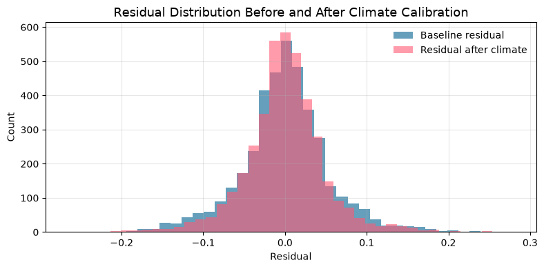

## Save outputs

```
Saved climate calibration outputs:
  - climate_parameters_lambda_xr_2004_2025_excl_2020_2021_age20_85.csv
  - climate_calibration_panel_2004_2025_excl_2020_2021_age20_85.csv
  - climate_calibration_diagnostics_2004_2025_excl_2020_2021_age20_85.csv
  - climate_calibration_summary_2004_2025_excl_2020_2021_age20_85.csv
  - climate_adjusted_fitted_mortality_2004_2025_excl_2020_2021_age20_85.csv
```

## Output Manifest

This final cell writes the Notebook 04 output manifest. Downstream notebooks should read this manifest rather than reconstructing file names manually.

```
Saved Notebook 4 output manifest:
04_climate_calibration_output_manifest.csv

==============================================================================
✅ NOTEBOOK 4 COMPLETE
==============================================================================
Please review the calibrated lambda parameters, diagnostics, and output files listed above.
Next step: run Notebook 5 — 05_projection_engine.ipynb
==============================================================================
```